# ml_example

Mario Catuogno & Francesco Pastore

13 September 2016

## Project description

For further information about the project, read [here](https://github.com/MarioCatuogno/IMDb).

## Problems with the dataset

The first problem we have faced was the extension of the IMDb database. It is composed of **.list** files which cannot be read and transformed as normal **.csv** files. For the purpose of this exercise we used a subset of movies from IMDb, downloaded from the personal page of one of us, which contains only few variables and few observation. We spent far too many hours understanding how to read **.list** files, for that reason maybe we have neglected a little bit the scripting part, trying to find a way to work with IMDb database.

## Import and data cleansing

```r
## Set working directory
setwd("/Users/mariocatuogno/Dropbox/Github/IMDb")
## Import raw data [Package: readr]
raw_data <- read_csv("data/raw_data.csv")
```

The “**raw_data**” dataset, downloaded from IMDb, weights **113KB** and has **526 observation** and **16 variables**. We decided to cleanse the dataset because there were some variables with NAs and others that cannot be used for analysis (e.g. URL variable).

```r
## Select only "Feature Film" discarding "TV Series" [Package: dplyr]
raw_data <- raw_data %>%
  tbl_df %>%
  filter(`Title type` == "Feature Film")
## Select and rename columns [Package: dplyr]
raw_data <- raw_data %>%
  select(movie_id = const,
         movie_title = Title,
         movie_genre = Genres,
         movie_runtime = `Runtime (mins)`,
         movie_year = Year,
         date_release = `Release Date (month/day/year)`,
         cast_director = Directors,
         rating_personal = `You rated`,
         rating_IMDb = `IMDb Rating`,
         num_votes = `Num. Votes`)
## Select only the first movie genre as main genre, deleting secondary genres
raw_data$movie_genre <- gsub(".*,", "", raw_data$movie_genre)
## Select only the first director as main director, deleting secondary directors
raw_data$cast_director <- gsub(".*,", "", raw_data$cast_director)
```

Then we started the cleansing of the raw dataset. The **raw_data** contained both movies and TVshows, so we decided to consider only movies, deleting TVshows records. The following step was to clean the dataset renaming each variable (*there were some variables with spaces in the name and some with only NA*) and selecting only the ones useful for our project.

```r
## Save the newly created dataset, to speedup the import process [Package: readr]
write_csv(raw_data, "data/clean_data.csv")
```

Once finished the cleansing process (*the dataset was already clean*), we saved the data frame into a new **.csv** file in order to speed up the importing process.

## Data exploration

```r
## Set working directory
setwd("/Users/mariocatuogno/Dropbox/Github/IMDb")
## Import cleansed data
data <- read.csv("data/clean_data.csv")
## Check the structure of the dataset
str(data)
```

```
## 'data.frame':    507 obs. of  10 variables:
##  $ movie_id       : Factor w/ 507 levels "tt0035423","tt0046912",..: 501 342 477 149 475 416 503 326 5 505 ...
##  $ movie_title    : Factor w/ 507 levels "2012","3:10 to Yuma",..: 401 406 109 25 197 329 500 490 93 58 ...
##  $ movie_genre    : Factor w/ 21 levels " adventure"," comedy",..: 6 12 5 4 6 13 13 6 20 13 ...
##  $ movie_runtime  : int  106 110 97 102 95 123 144 123 95 147 ...
##  $ movie_year     : int  2016 2016 2016 2000 2016 2016 2016 2016 1964 2016 ...
##  $ date_release   : Factor w/ 492 levels "1954-05-18","1954-08-01",..: 486 491 490 145 480 492 488 489 4 487 ...
##  $ cast_director  : Factor w/ 271 levels " Andrew Stanton",..: 143 79 2 173 18 75 61 86 238 21 ...
##  $ rating_personal: int  6 4 7 6 6 5 7 6 6 8 ...
##  $ rating_IMDb    : num  7.6 6.4 7.7 7.6 7.2 6.7 7.2 7.2 8.5 8 ...
##  $ num_votes      : int  141095 65533 69243 361970 71044 218847 188822 140047 346512 322564 ...
```

For further analysis and exploration we have used the cleansed dataset. Above there is the structure of the data frame. The newly cleansed dataset weights **42KB** and has **507 observation** and **10 variables**.

```r
movie_runtime_genre <- data %>%
  group_by(movie_genre) %>%
  summarise(mean = mean(movie_runtime))
```

Just to do an exploratory analysis, we were curious to see the average **movie runtime** for each genre and we have discovered that **Adventure movies** have the highest average runtime (*163 min*), while the **Family movies** have the lowest one (*97 min*).

## Data visualization

```r
# Create data frame with frequencies for each movie genre
movie_genre <- c("Action", "Adventure", "Crime", "Drama", "Comedy", "Family",
                 "Fantasy", "History", "Horror", "Musical", "Mystery", "Romance",
                 "SciFi", "Sport", "Thriller", "War", "Western")
movie_freq <- c(2, 11, 11, 46, 22, 20,
                53, 1, 4, 4, 15, 53,
                76, 10, 151, 19, 9)
movie_genre_freq <- data.frame(movie_genre, movie_freq)
rm(movie_genre, movie_freq)
```

`ggplot` has some problem with the reordering of levels of a factor. For that reason we have created a data frame with the frequencies for each movie genres (*movies seen of that specific genre*).

```r
# Arrange levels of factor by frequency
movie_genre_freq$movie_genre <- factor(movie_genre_freq$movie_genre, levels = movie_genre_freq$movie_genre[order(movie_genre_freq$movie_freq)])
```

In order to plot the frequencies in descending order, was necessary to sort the levels of the factor, based on the frequency.

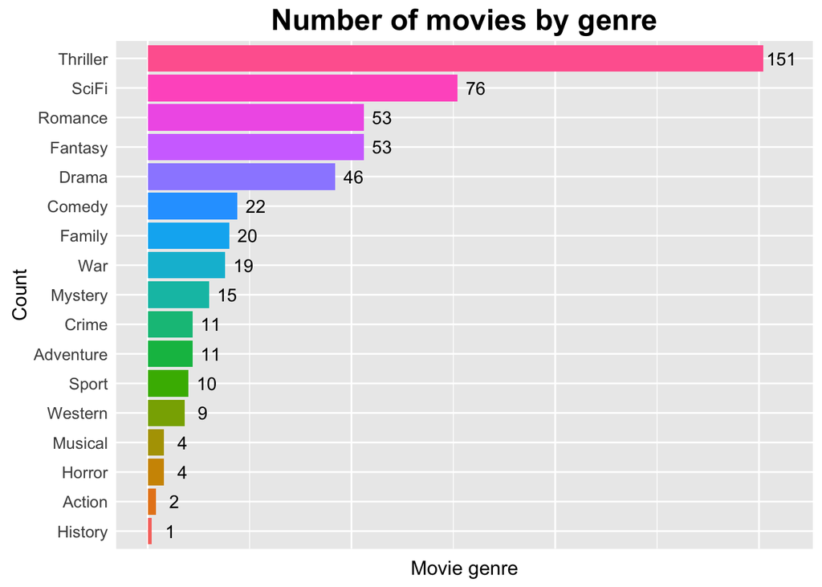

```r
## P1: Number of movies by genre
p1 <- ggplot(data = movie_genre_freq, aes(x = movie_genre, y = movie_freq, label = movie_freq, fill = movie_genre)) +
  geom_bar(stat = "identity") + geom_text(nudge_y = 4.5) + coord_flip() +
  labs(x = "Count", y = "Movie genre", title = "Number of movies by genre") +
  theme(plot.title = element_text(face = "bold", size = 18),
        axis.text.x = element_blank(),
        axis.text.y = element_text(size = 10),
        axis.title = element_text(size = 12),
        axis.ticks = element_blank(),
        legend.position = "none",
        legend.text = element_text(face = "italic", size = 10),
        legend.title = element_blank())
plot(p1)
```

From this plot we can see that the most seen movie genre is **Thriller**, followed by **SciFi** and **Fantasy/Romance**. The least seen movie genre is **History**. It appears that “pure” **Action** movies are rare, meaning that most of the action movies are categorized with another “main” genre.

[figure not shown]

```r
# P2: Show the correlation between IMDb ratings and personal ratings
p2 <- ggplot(data = data, aes(x = rating_IMDb, y = rating_personal, colour = rating_personal)) + geom_jitter() +
  scale_y_continuous(limits = c(1,10), breaks = c(1,3,5,7,9)) +
  scale_x_continuous(limits = c(1,10), breaks = c(1,3,5,7,9)) +
  scale_color_continuous(low = "#D73027", high = "#1A9850") +
  labs(x = "IMDb ratings", y = "Personal ratings", title = "Correlation between \n IMDb and personal ratings") +
  theme(plot.title = element_text(face = "bold", size = 18),
        axis.text.x = element_text(size = 10),
        axis.text.y = element_text(size = 10),
        axis.title = element_text(size = 12),
        axis.ticks = element_blank(),
        legend.position = "none",
        legend.text = element_text(face = "italic", size = 10),
        legend.title = element_blank())
plot(p2)
```

It could be interesting to see the correlation between **personal ratings** and **IMDb average ratings**. To do so, we used `ggplot` to create a **scatter plot** with personal and website ratings. It is clear that, more or less, the personal ratings follow the pattern of IMDb ratings, with some exceptions (*highest vote for personal rating is 9, while on IMDb there are ratings higher than this value*). To better show the results we have used `geom_jitter` instead of the traditionla `geom_point`.